Alonso Ramírez Hernández · CENES–UPTC · 8 de septiembre de 2026

# De los resultados al producto

Sesión 4 · Resultados, figuras y ensamblaje

00

Momento 0

## El sistema crece

Hoy entra la carpeta de resultados

Dónde vamos

## La casilla 04: la única que da DOS secciones

Lo que produce hoy

- Los **resultados** que sobrevivieron
- Los **límites**: lo que no se puede decir
- Una **figura** que se defiende sola

Dónde aterriza

- Sección de **Resultados**
- Sección de **Límites**
- El exhibit central del paper

Es la única sesión del curso que produce **dos secciones**.

Manos · 15 min

## Se amplía la carpeta

| Se agrega | Para qué |
| --- | --- |
| `05_salidas/` | la figura, las tablas y el texto que se entrega |
| `05_salidas/resultados.md` | los resultados y los límites, juntos |
| `02_decision/` · actualizar | qué se descartó hoy y por qué |

Regla de hoy: **una figura sin su límite escrito al lado no está terminada.**

Un resultado en el que no intentaste matarlo  
no es un resultado: es una primera impresión.

La tesis de la sesión

01

Momento 1

## De la carpeta a la figura

El demo · 30 minutos

El demo · lo que voy a pedir

## Una sola instrucción, cuatro pasos

1

Leer la carpeta

que lea los datos y me diga qué hay

2

Descriptivos

medias, conteos, la distribución

3

Diferencia de medias

el primer contraste, todavía sin modelo

4

La regresión y la figura

y que me la guarde en `05_salidas/`

Todo en **una conversación**. Sin cambiar de ventana, sin pegar nada.

Lo que se señala mientras corre

## Tres cosas que no hace la máquina

No decide la muestra

Qué filas entran y cuáles no. Eso lo decidí yo — y el sábado vimos que esa línea da vuelta al resultado.

No sabe qué es plausible

Un coeficiente de 0,9 en esta escala sería absurdo. Ella no lo sabe; yo sí.

No pone los límites

Los límites salen de conocer el terreno, no el dato.

Escribe el código en segundos. **El criterio sigue costando lo mismo.**

02

Momento 2

## La misma pregunta, dos respuestas

El análisis del sábado, corrido dos veces

Lo que no se cuenta en los papers

2

corridas, dos veredictos opuestos

El mismo análisis, los mismos datos, la misma pregunta. Lo único que cambió fue **una línea: cómo se define la muestra.**

Análisis de contratación municipal · N-050

Las dos corridas

## Misma pregunta. Respuestas contrarias.

Parecía razonable

Primera · 309 municipios

Criterio: los que reportan en los cinco años. Resultado **débil**, no pasa la corrección por pruebas múltiples y **se cae al quitar un decil**.  
Veredicto: **no hay efecto.**

Después de mirar por dentro

Segunda · 146 municipios

Criterio: al menos **50 contratos cada año**. Resultado **+0,275, p 0,003**, aguanta las cuatro pruebas y aparece el gradiente.  
Veredicto: **hay efecto.**

No se cambió el dato. Se cambió **quién entra en el análisis**.

La tabla que delató a la primera muestra

## Miren el municipio típico

| Año | Mediana de contratos | Mediana de contratación directa |
| --- | --- | --- |
| 2021 | 11 | 0,18 |
| 2022 | 33 | 0,50 |
| 2023 | 157 | 0,71 |
| 2024 | 309 | 0,84 |
| 2025 | 338 | **0,81** |

SECOP II · muestra de la primera corrida (309 municipios)

De **11 contratos a 338** y de **18 % a 81 %**. Eso no es un cambio de conducta: es un municipio que **empezó a usar la plataforma**.

Las cuatro pruebas de la segunda corrida

## Ninguna de las cuatro se pidió por cortesía

1

Primeras diferencias

colapsar a un antes y un después, sin dummies — **p 0,001**

2

Quitar el decil de arriba

de 146 a 131 municipios — **+0,233, p 0,022**

3

Bonferroni sobre 5 resultados

umbral 0,010 — **pasa el de valor, no el de conteo**

4

¿Hay gradiente por deciles?

sube a lo largo de la distribución, no es una punta

La primera corrida **murió en la prueba 2**. La segunda pasó las cuatro.

El chequeo que confirma que no hay error

## Dos caminos distintos, el mismo número

Efectos fijos

+0,2750

Primeras diferencias

+0,2750

Por qué tiene que pasar

Con panel balanceado y un tratamiento que cambia una sola vez, las dos cosas **tienen que** coincidir. Que coincidan dígito a dígito confirma que la especificación con dummies estima lo que se dijo — y no otra cosa.

Si **no** hubieran coincidido, habría un error en alguna de las dos. Ese es el chequeo, y es gratis.

Y una trampa de lectura

## Perder significancia no es perder el efecto

| Muestra | N | Coeficiente | p |
| --- | --- | --- | --- |
| Completa | 146 | +0,2750 | 0,001 |
| Sin el decil superior | 131 | +0,2327 | 0,022 |
| Sin los **dos** deciles extremos | 116 | +0,2406 | 0,144 |
| Sin el 5 % de mayor cambio | 138 | +0,3066 | 0,006 |

En la tercera fila el punto estimado **sube** y el error estándar **se duplica** al quitar 30 municipios. Es pérdida de potencia, no ausencia de efecto.

03

Momento 3

## Un resultado de verdad

Y qué pasa cuando no sobrevive

El caso

## Redistricting y distancia ideológica

Paper II · en curso

La pregunta

¿Cambiar quién dibuja los distritos electorales mueve la polarización de los congresistas?

Identificación

El diseño

Variable instrumental sobre **349 incumbentes en 41 estados**. Instrumento fuerte: F entre 60 y 76.

Instrumento fuerte, panel grande, pregunta buena. **Todo bien hasta acá.**

El resultado

+0,274

y no significa nada

El efecto estimado en segunda etapa. **p = 0,162.** El intervalo de Anderson–Rubin contiene el cero.

Paper II · panel 349/41, ciclo 2020

Y la puntilla

## El instrumento predice el pasado

Exogeneidad en duda

La prueba que lo mató

El instrumento predice el HHI de **2018** — un resultado **anterior** al tratamiento (p = 0,036). Si predice algo que ocurrió antes, no está capturando el efecto del tratamiento: está capturando algo que ya estaba ahí.

Se retiró el resultado. **No se publicó, no se maquilló, no se buscó otra especificación.**

Y también tuvo sus idas y vueltas

## Cuatro rondas antes de retirarlo

1

Validar la medida

el índice se comparó contra otra construcción — **correlación 0,989**

2

Retirar una medida

la versión «con signo» no se sostenía y **se descartó**

3

Comprobar el instrumento

F entre 60 y 76 — **fuerte, sin duda**

4

La prueba de exogeneidad

predice el pasado — **y ahí se acabó**

Las tres primeras rondas **salieron bien**. Un resultado no se muere por fallar todo: se muere por fallar **una**.

Descartar un resultado propio es caro.  
Por eso casi nadie lo enseña.

Y por eso está en este curso

04

Momento 4

## Del resultado a la presentación

El demo estrella · 35 minutos

Lo que voy a mostrar

## La misma evidencia, dos productos

El paper

- Plantilla académica en LaTeX
- Secciones separadas en archivos
- La figura entra por referencia, no pegada
- Bibliografía en `.bib`

La presentación

- Plantilla Beamer académica
- Las mismas figuras
- Otro registro: una idea por lámina
- Sale en minutos, no en horas

No es magia: es **una plantilla y una carpeta ordenada**.

Por qué sale rápido

## Lo que hizo posible el minuto de hoy

1

La carpeta tiene estructura

cada cosa vive donde va, desde la sesión 2

2

Las figuras se regeneran

no están pegadas: se producen del dato

3

La plantilla ya existe

se escribió una vez, se usa siempre

4

Las cifras vienen del archivo

no se teclean, y por eso no se equivocan

El trabajo no se hizo hoy. **Se hizo antes, y hoy se cobra.**

05

Momento 5

## Las tres actividades

Manos · 80 minutos

Actividad 1 · 25 min · Colab

## ¿Cuál de estos resultados sobrevive?

Reales, no de ejemplo

Los datos

`resultados-did.csv` del sitio del curso. Son los **cinco resultados reales** del análisis de contratación que vimos el sábado, sobre los mismos 146 municipios.

Lo que hacen

Le piden al agente un gráfico de coeficientes con su intervalo, y que pinte de color solo los que pasen el umbral de **0,05 dividido entre 5**.

El prompt completo está en las instrucciones del sitio.

Lo que les va a salir

## Uno pasa. Cuatro no.

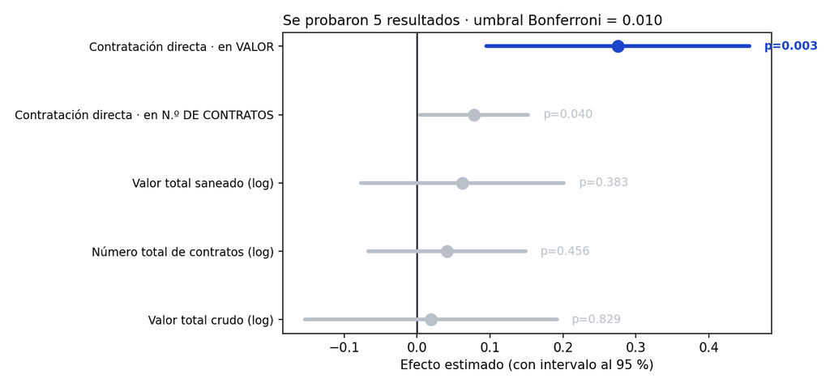

Análisis de contratación municipal · 146 municipios · N-050

Las tres preguntas de la actividad 1

1

¿Cuántos resultados quedan de color?

2

El segundo tiene **p = 0,040**. En cualquier clase les enseñaron que eso es significativo. **¿Por qué queda gris?**

3

Si yo hubiera probado **solo** esa variable, ¿el resultado sería distinto? ¿Cambió el dato, o cambió lo que yo hice?

Probar muchas cosas y reportar la que salió es **la forma más común de engañarse sin mentir.**

Actividad 2 · 25 min

## La misma cifra, tres audiencias

| Para | Cuánto | Qué tiene que llevar |
| --- | --- | --- |
| El paper | 3–4 renglones | magnitud, incertidumbre y **el límite**, en la misma frase |
| Una lámina | 1 renglón | solo lo que se entiende de un vistazo, sin p ni error estándar |
| Quien decide | 2 renglones | qué decisión cambia, y qué **no** se puede concluir |

La trampa: casi todos escriben la de lámina **sin el límite** — y esa es la que se viraliza.

Actividad 3 · 30 min

## Ensamblar · la casilla 04

Lo que se entrega

`05_salidas/resultados.md` con la figura de la actividad 1, el párrafo de la actividad 2, y una sección de **Límites** con tres viñetas.

El prompt lleva una instrucción rara, y es a propósito

«En Límites, sé **más duro conmigo** de lo que sería un evaluador.»

Una figura sin su límite escrito al lado **no está terminada**.

Al sistema

## Se marca la casilla 04

01Ideación

02Literatura

03Datos

04Análisis

05Escritura

06Comunicación

Cuatro de seis. El jueves: escritura y figuras. El sábado: se engrana todo.

La herramienta produce.  
El investigador acepta o rechaza.

Y hoy practicamos rechazar